# IntroLab

**Цель работы:** на предоставленных задачах освоить азы языка R и среды для его выполнения Rstudio Visual Studio

### Задание 1

Посчитать:

- 35 + 777
- 13 * 47
- 675 * 15
- 849 * 629

```r
35 + 777
```

```
## [1] 812
```

```r
13 * 47
```

```
## [1] 611
```

```r
675 * 15
```

```
## [1] 10125
```

```r
849 * 629
```

```
## [1] 534021
```

### Задание 2

Умножьте 11111111 само на себя. Теперь умножьте на 1111111?. О чём говрит ошибка?

```r
a <- 11111111
a * a * 1111111#?.
```

```
## [1] 1.371742e+20
```

Возникает ошибка при компиляции, которая не имеет представления что делать с “?”

[figure not shown]

### Задание 3

Найдите площади примоугольников с длинами (3,7,12,15,20) и ширинами (2,5,8,11,15)

```r
recArea <- function(a, b) {
    S <- a * b
    return(S)
}

lnVect <- c(3, 7, 12, 15, 20)
wdVect <- c(2, 5, 8, 11, 15)
recArea(lnVect, wdVect)
```

```
## [1]   6  35  96 165 300
```

Для нахождения площади прямоугольника была использована формула: $S = a * b$, где *a* - высота прямоугольника, *b* - его длина

### Задание 4

Постройте график этих длин и ширин

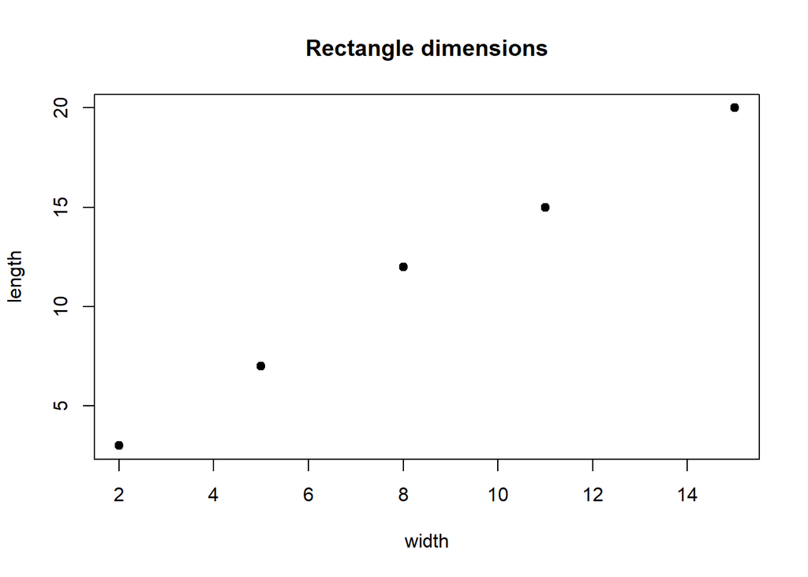

```r
plot(wdVect, lnVect, type = "p", xlab = "width", ylab = "length", main = "Rectangle dimensions", bg = "black", pch = 21)
```

### Задание 5

Первокурсник Вася тратит очень мног овремени на домашнюю работу. 40 минут на математику, 40 на английский, 10 на физкультуру и 150 минут на программирование. Постройте график.

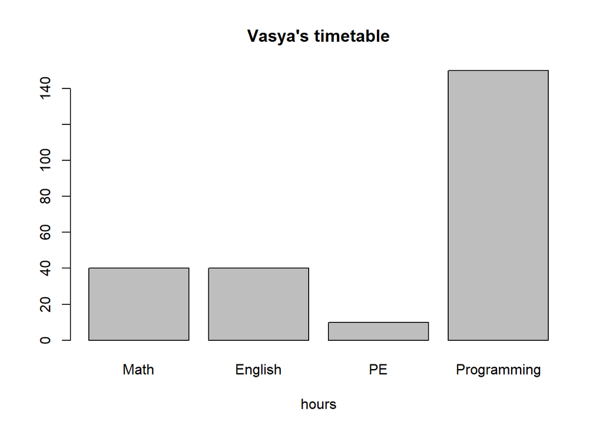

```r
timeBar <- c("Math" = 40, "English" = 40, "PE" = 10, "Programming" = 150)
barplot(timeBar, main = "Vasya's timetable", xlab = "hours", pch = "x")
```

### Задание 6

Напитки разливаются вручную в банки по 455 мл, количество налитого нормально распределено со средним значением 450 мл. и стандартным отклонением 4 мл. Смоделируйте разливание в 10000 бутылок и расчитайте вероятность переливания банки.

```r
n <- 10 ^ 4
rule <- 455
drinks <- rnorm(n, mean = 450, sd = 4)
print(paste("Chance of overfill: ", mean(drinks > 455) * 100, "%"))
```

```
## [1] "Chance of overfill:  10.56 %"
```

# Заключение

В ходе выполнения данной работы я получил незабываемый опыт и приобрел навыки, которые пригодятся в дальнейшей профессиональной деятельности. Были изучены и закреплены на практике основы R, а также навыки создания и оформления отчетов.

С уважением,

студент гр. РИ-440005

Кабанов Евгений